# Gesture elicitation as a computational optimization problem

Case study: Optimizing the Métamorphe keyboard

Theophanis Tsandilas

Université Paris-Saclay, CNRS, Inria, LISN

Pierre Dragicevic

Université de Bordeaux, CNRS, Inria, LaBRI

This page demonstrates how to use our R code and apply our optimization methods (Tsandilas and Dragicevic 2022) to the gesture elicitation study of Bailly et al. (2013).

## The study

Bailly et al. (2013) investigated gestural shortcuts for their Métamorphe keyboard. Métamorphe is a keyboard with actuated keys that can sense user gestures, such as pull, twist, and push sideways. In this study, **20 participants** suggested a keyboard shortcut for **42 referents** on a Métamorphe mockup. Proposing a shortcut required choosing (i) a key and (ii) the gesture applied to the key. The participants produced a total of 71 unique keys, 27 unique gestures, and 358 unique combinations of keys and gestures. Our elicited **sign set** is the set of those 358 unique combinations (our **signs**).

## The optimization problem

Our goal is to find an optimal set of mappings between signs (combinations of keys and gestures) and referents. We denote this optimal **sign mapping set** as $\pi_{opt}$. Now, to define the optimization problem, we require:

1. An *objective function*. We aim to maximize **guessability** (Wobbrock et al. 2005), where guessability $G(\pi)$ can be defined as the probability that the sign of a gesture performed by a random user for a random referent belongs to the sign mapping set $\pi$.
2. A set of *design constraints*. We will require each referent to be mapped to a single and unique sign.

Ideally, we should find a sign mapping set that is optimal for the full population of users. In practice, however, we can only provide an estimate $\widehat\pi_{opt}$ of the optimal mapping set based on a sample, i.e., the participants of the study. Since $\widehat\pi_{opt}$ is not necessarily optimal, that is, $G(\widehat\pi_{opt}) \le G(\pi_{opt})$, we would like to:

1. Quantify our uncertainty (or confidence) about $\pi_{opt}$ given the current sample
2. Determine a sample size such that $G(\widehat\pi_{opt})$ is close enough to $G(\pi_{opt})$

## Read the dataset

[This is the original dataset](https://github.com/gelicopt/gelicopt.github.io/blob/main/datasets/bailly2013.csv) as provided by the authors.

As a first step, we need to read the data:

```r
data <- read.csv("datasets/bailly2013.csv", stringsAsFactors=F)

# For each participant, there are five columns, where the first captures the key and the second captures the gesture
keys <- data[, seq(2, ncol(data), by=5)] # These are participants' proposals of keys
gestures <- data[, seq(3, ncol(data), by=5)] # These are participants' proposals of key gestures

# Also build a table with keys + gestures combined.
keys_gestures = data.frame(keys)
for (r in 1:nrow(keys_gestures)) {
    keys_gestures[r,] = paste0(keys_gestures[r,], "-", gestures[r,])
}

# Replace the column names by participant IDs
pIDs = paste0("P", 1:ncol(keys))
names(keys_gestures) <- pIDs

# Replace the row names by referent IDs
row.names(keys_gestures) <- data$cmd
```

The resulting *keys_gestures* data frame is as follows (scroll to see details):

|  | P1 | P2 | P3 | P4 | P5 | P6 | P7 | P8 | P9 | P10 | P11 | P12 | P13 | P14 | P15 | P16 | P17 | P18 | P19 | P20 |
| --- | --- | --- | --- | --- | --- | --- | --- | --- | --- | --- | --- | --- | --- | --- | --- | --- | --- | --- | --- | --- |
| Accept | Y-pull | Y-top | F9-towards | enter-top | enter-top | A-top | Y-top | enter-top | enter-towards | Y-top | A-pull | X-left | Y-top | esc-towards | enter-top | A-top | +-top | M-LR | A-top | Y-LR |
| Align bottom | A-towards | A-towards | shift-towards | A-towards | A-towards | B-towards | A-towards | A-top+towards | –towards | A-towards | B-towards | A-towards | A-towards | F6-towards | J-towards | A-towards | win-towards | J-towards | O-top | A-towards |
| Align justify | A-pull | A-LR | shift-pull | shiftR-LR | A-away | J-top | A-FB | J-top | \|-left+right(wiggle) | J-right | J-pull | J-push | A-top | F1-pull | J-pull | A-pull | +-LR | J-LR | J-right | A-pull |
| Align left | A-left | A-left | shift-left | A-left | A-left | A-left | A-left | A-top+left | [-left | A-left | L-left | A-left | A-left | F6-left | J-left | A-left | menu-left | J-left | [-left | A-left |
| Align middle | A-FB | A-FB | shift-top | A-FB | A-top | D-towards | A-LR | A-top | +-pull | A-FB | M-FB | A-FB | A-FB | F6-top | J-top | A-top | win-LR | J-top | %-top | A-FB |
| Align right | A-right | A-right | shift-right | A-right | A-right | A-right | A-right | A-top+right | ]-right | A-right | R-right | A-right | A-right | F6-right | J-right | A-right | win-right | J-right | ]-right | A-right |
| Align top | A-away | A-away | shift-away | A-away | A-away | T-top | A-away | A-top+away | –right | A-away | T-away | A-away | A-away | F6-away | J-away | A-away | win-away | J-away | O-pull | A-away |
| Close | X-top | O-pull | esc-LR | X-away | backspace-CCW | C-top | backspace-top | esc-top | F4-away | X-top | C-LR | C-top | O-towards | esc-top | F4-top | C-top | win-CCW | P-CCW | spacebar-top | C-top |
| Copy | C-top | C-top | C-towards | capslock-FB | C-away | C-towards | C-top | C-top | C-towards | C-LR | C-top | C-FB | C-top | C-top | C-top | C-LR | +-top-double | K-FB | C-top | C-top |
| Cut | C-away | X-top | X-top | capslock-LR | X-away | C-away | C-LR | X-top | C-away | C-pull | X-top | C-LR | X-top | backspace-LR | X-top | C-pull | –left | K-pull | C-away | X-top |
| Decrease volume | V-CCW | P-towards | spacebar-CCW | ctrlR-CCW | –away | V-towards | <-towards | spacebar-towards | 7-CCW | V-CCW | V-towards | V-CCW | –top | –CCW | –top | –CCW | win-CCW | ?-left | V-towards | V-CCW |
| Delete | D-pull | backspace-top | backspace-top | D-away | backspace-top | D-top | D-top | backspace-top | backspace-pull | D-top | D-pull | D-top | backspace-top | backspace-top | backspace-LR | backspace-top | –right | U-top | D-top | D-CCW |
| Duplicate | C-directional | D-directional | 6-CW | 2-LR | +-away | D-away | D-CW | C-top+directional | 2-pull | D-top(double) | D-top | D-pull | D-top | V-FB | shiftL-top | D-LR | menu-top-double | U-right | D-pull | D-top |
| Enlarge | D-CW | ^-away | +-pull | E-towards | +-pull | E-top | enter-right | +-away | +-CCW | L-pull | E-pull | E-left | S-CW | F12-pull | A-CW | +-right | +-CW | U-pull | O-CW | S-CW |
| Find | F-top | F-top | F-top | F-towards | F-away | F-top | F-top | F-top | F-FB | F-CCW | F-left | F-top | F-top | F-top | F-top | F-top | +-FB | L-top | F-top | F-top |
| Find next | F-right | F-right | tab-right | enter-right | >-CW | F-away | F-right | F-right | >-right | F-towards | F-towards | F-CW | F-left | F-CW | F-right | F-right | +-away | L-towards | F-right | F-right |
| Find previous | F-left | F-left | tab-left | backspace-CCW | <-CCW | P-right | backspace-left | F-left | <-left | F-away | F-away | F-CCW | F-right | F-CCW | F-left | F-left | win-left | L-away | F-left | F-left |
| Help | 1-away | esc-top | H-pull | ?-top | ?-away | H-top | ?-top | F1-top | menu-pull | H-pull | H-top | H-left | H-top | F5-FB | F9-top | menu-FB | +-pull | M-pull | H-pull | H-top |
| Increase volume | V-CW | P-away | spacebar-CW | ctrlR-CW | +-away | V-top | >-away | spacebar-away | 7-CW | V-CW | V-away | V-CW | +-top | +-CW | +-top | +-CW | win-CW | ?-right | V-away | V-CW |
| Insert | I-top | I-towards | shift-top | enter-top | I-away | I-top | P-LR | ^-away | I-left+right(wiggle) | I-towards | I-top | I-left | I-top | I-FB | I-top | I-towards | –top-double | U-CW | I-top | I-FB |
| Maximize | M-away | tab-away | 9-away | S-towards | +-CW | M-top | enter-right | M-away | F1-pull | D-pull | M-left | M-pull | +-CW | F9-CW | M-pull | +-top | +-CW | M-pull | spacebar-pull | M-pull |
| Menu access | win-top | esc-towards | menu-top | menu-top | M-away | Q-top | menu-LR | menu-top | menu-top | M-LR | M-top | M-top | menu-top | F5-pull | F10-top | menu-top | menu-FB | M-away | menu-top | M-CW |
| Minimize | M-towards | tab-towards | 1-towards | M-away | –CCW | M-towards | enter-left | M-towards | F1-LR | D-top | M-left | M-CCW | –CCW | F9-CCW | M-top | –top | –CCW | M-top | spacebar-top | M-FB |
| Move a little | Q-left | N-directional | F1-directional | tab-LR | </>-left/right | L-towards | M-directional | ctrl-directional | tab-directional | B-directional | >-top | M-left/right | N-directional | F12-directional+LR | comma-directional | M-right | win-right | U-pull | O-left(pulse)/right(pulse) | J-directional |
| Move a lot | Q-away | M-directional | F12-directional | tab-FB | </>-pull | L-away | M-directional | ctrl-directional | capslock-directional | L-directional | >-pull | M-left/right | M-directional | F9-directional+LR | .-directional | M-LR | –right | U-FB | O-left(long)/right(long) | L-directional |
| Next | >-top | tab-right | N-right | 2-right | >-top | N-top | >-right | spacebar-right | backspace-right | H-right | N-right | N-right | >-top | ~-right | F-CW | N-right | win-right | L-right | >-right | N-left/right |
| Open | O-top | O-top | enter-top | enter-pull | O-away | O-top | O-top | enter-top | F4-towards | O-pull | O-top | O-top | O-away | O-pull | enter-top | O-pull | menu-CW | M-CW | spacebar-pull | O-top |
| Pan | G-left/right | P-directional | tab-left/right | spacebar-FB | Shift-left/right | P-left/right | M-directional | win-directional | shift-directional | S-directional | V-CW | O-left/right | V-directional | F6-directional+LR | ?-directional | tab-directional | menu-FB | L-left | spacebar-left/right | P-CW/CCW |
| Paste | C-towards | V-towards | V-top | 1-top | V-away | P-top | P-LR | V-top | +-towards | V-top | V-top | V-left | V-top | V-top | V-top | P-top | –top-double | K-LR | P-top | V-top |
| Pause | V-top | P-top | spacebar-top | >-top | P-towards | P-towards | spacebar-top | spacebar-top | doublequote-FB | P-top | P-pull | L-LR | spacebar-top | ~-pull | spacebar-top | P-away | –top | ?-push | =-towards | P-FB |
| Play | V-top | P-top | spacebar-top | >-right | P-away | Y-top | spacebar-top | spacebar-top | enter-LR/FB | P-LR | P-top | L-top | enter-top | ~-top | spacebar-top | P-towards | +-top | ?-CW | =-away | T-top |
| Previous | <-top | tab-left | P-left | 1-left | <-top | X-top | backspace-left | spacebar-left | backspace-left | H-left | P-left | P-left | <-top | ~-left | F-CCW | P-left | win-left | L-left | <-left | P-left |
| Reject | X-pull | N-top | F8-away | R-away | backspace-top | J-away | N-top | esc-top | X-towards | N-FB | R-pull | R-top | N-top | esc-away | backspace-top | R-top | –CCW | M-CCW | R-top | R-top |
| Rotate | R-CW/CCW | R-CW/CCW | menu-CW/CCW | R-FB | R-CW/CCW | R-top | R-CW/CCW | ctrl-CW/CCW | 0-CW/CCW | R-CW/CCW | R-CW | R-CW/CCW | R-CW/CCW | F12-CW/CCW | ^-CW/CCW | R-CW/CCW | win-FB+CW | U-CW/CCW | R-CW/CCW | R-CW/CCW |
| Save | S-top | S-pull | S-top | ctrl-top | S-away | S-top | S-top | S-top | S-FB | S-top | S-away | S-right | S-top | S-top | S-top | S-top | menu-top | P-left | S-top | S-top |
| Save all | S-FB | S-FB | F4-pull | ctrlL-pull | S-CW | L-top | S-LR | S-top+away | S-pull | A-top | S-left | S-top | S-pull | S-LR | S-pull | S-left | +-CW | P-top | S-LR | H-CW |
| Save as | S-pull | S-top | F5-top | ctrlL-pull | S-right | S-left | S-top | S-towards | S-towards | S-pull | S-right | S-left | S-right | S-FB | S-directional | S-right | win-top-double | P-right | F1-top | S-pull |
| Shrink | D-CCW | ^-towards | –LR | S-away | –top | K-top | enter-left | –towards | +-CCW | S-FB | E-top | S-top | S-CCW | F12-top | A-CCW | –left | –CCW | U-CCW | O-CCW | S-CCW |
| Task switch | tab-left/right | tab-CW/CCW | win-towards | tab-pull | >-CW/CCW | W-top | T-left/right | tab-left/right | tab-CW/CCW | S-left | W-top | T-left | W-left/right | F5-LR | tab-top | win-right | menu-right | M-LR | spacebar-CW/CCW | T-towards |
| Undo | U-top | Z-top | backspace-CCW | shiftR-CCW | backspace-left | U-top | backspace-top | <-top | U-pull | Z-CCW | U-top | U-left | Z-top | backspace-away | Z-top | backspace-left | win-CCW | P-left | U-pull | U-CCW |
| Zoom in | Z-away | Z-away | +-top | Z-towards | Z-CW | Z-top | enter-right | win-top | Z-right | Z-pull | Z-CW | Z-top | Z-CW | F9-pull | Q-top | Z-CW | win-CW | L-CW | Z-CW | Z-FB |
| Zoom out | Z-towards | Z-towards | –pull | Z-away | Z-CCW | Z-away | enter-left | win-pull | Z-left | Z-top | Z-CCW | Z-pull | Z-CCW | F9-top | Q-pull | Z-CCW | win-CCW | L-CCW | Z-CCW | Z-pull |

## Estimate the optimal sign mapping set

We use a **sign mapper** that is based on the [Hungarian algorithm](https://en.wikipedia.org/wiki/Hungarian_algorithm) to solve the optimization problem.

```r
source("gelicopt/sign-mappers.R") # Implementation of various sign mappers

mappings <- hungarian_sign_mapper(keys_gestures)
```

The resulting *mappings* data frame is the following (scroll to see details):

| refname | ref | sign |
| --- | --- | --- |
| Accept | 1 | Y-top |
| Align bottom | 2 | A-towards |
| Align justify | 3 | A-pull |
| Align left | 4 | A-left |
| Align middle | 5 | A-FB |
| Align right | 6 | A-right |
| Align top | 7 | A-away |
| Close | 8 | esc-top |
| Copy | 9 | C-top |
| Cut | 10 | X-top |
| Decrease volume | 11 | V-CCW |
| Delete | 12 | backspace-top |
| Duplicate | 13 | D-top |
| Enlarge | 14 | +-pull |
| Find | 15 | F-top |
| Find next | 16 | F-right |
| Find previous | 17 | F-left |
| Help | 18 | H-top |
| Increase volume | 19 | V-CW |
| Insert | 20 | I-top |
| Maximize | 21 | M-pull |
| Menu access | 22 | menu-top |
| Minimize | 23 | –CCW |
| Move a little | 24 | N-directional |
| Move a lot | 25 | M-directional |
| Next | 26 | N-right |
| Open | 27 | O-top |
| Pan | 28 | L-left |
| Paste | 29 | V-top |
| Pause | 30 | spacebar-top |
| Play | 31 | P-top |
| Previous | 32 | P-left |
| Reject | 33 | R-top |
| Rotate | 34 | R-CW/CCW |
| Save | 35 | S-top |
| Save all | 36 | S-pull |
| Save as | 37 | S-right |
| Shrink | 38 | S-CCW |
| Task switch | 39 | tab-left/right |
| Undo | 40 | U-top |
| Zoom in | 41 | Z-CW |
| Zoom out | 42 | Z-CCW |

As we explained earlier, these mappings ($\widehat\pi_{opt}$) are not necessarily optimal for the full user population. To quantify our confidence about the optimal mappings, we use the bootstrap method, where we iteratively run the optimization algorithm after sampling with replacement from the original sample of the 20 participants:

```r
source("gelicopt/inference.R") # Implementation of bootstrapping used for inference

# Create the bootstrapping distribution. By default, it contains R = 200 samples.
# But you could set R to a different number.
boot_samples <- bootstrap(keys_gestures, hungarian_sign_mapper, R = 300)

# For each referent, get only signs with at least 10% confidence
signs <- getSigns(boot_samples, conf.min = .1)

# And we will then use it to flatten signs and confidence scores for presentation purposes
confidence_res <- data.frame(ref=row.names(keys_gestures), signConfidence = flatten(signs))
```

The resulting **confidence_res** data frame is the following (scroll to see details):

| ref | signConfidence |
| --- | --- |
| Accept | enter-top:0.40, Y-top:0.38, A-top:0.14 |
| Align bottom | A-towards:1 |
| Align justify | A-pull:0.42, J-top:0.13, J-pull:0.12, J-right:0.11 |
| Align left | A-left:1 |
| Align middle | A-FB:0.88 |
| Align right | A-right:1 |
| Align top | A-away:1 |
| Close | esc-top:0.27 |
| Copy | C-top:0.91 |
| Cut | X-top:0.79, C-away:0.17 |
| Decrease volume | V-CCW:0.50, V-towards:0.22 |
| Delete | backspace-top:0.77, D-top:0.21 |
| Duplicate | D-top:0.45, D-pull:0.20 |
| Enlarge | +-pull:0.27, S-CW:0.18 |
| Find | F-top:1 |
| Find next | F-right:0.96 |
| Find previous | F-left:0.93 |
| Help | H-top:0.46, H-pull:0.23, ?-top:0.12 |
| Increase volume | V-CW:0.53, +-top:0.11 |
| Insert | I-top:0.74, I-towards:0.17 |
| Maximize | M-pull:0.47, +-CW:0.33 |
| Menu access | menu-top:0.91 |
| Minimize | –CCW:0.40, M-towards:0.29, M-top:0.13 |
| Move a little | N-directional:0.19, win-right:0.13 |
| Move a lot | M-directional:0.44, L-directional:0.17 |
| Next | N-right:0.47, >-top:0.30, >-right:0.12 |
| Open | O-top:0.87 |
| Pan | menu-FB:0.15 |
| Paste | V-top:0.93 |
| Pause | spacebar-top:0.69, P-towards:0.12 |
| Play | P-top:0.15, spacebar-top:0.14, +-top:0.12 |
| Previous | P-left:0.63, <-top:0.20 |
| Reject | R-top:0.52, N-top:0.33 |
| Rotate | R-CW/CCW:0.99 |
| Save | S-top:1 |
| Save all | S-pull:0.30, S-LR:0.28, S-left:0.12, S-FB:0.10 |
| Save as | S-right:0.50, S-pull:0.22, S-towards:0.12 |
| Shrink | S-CCW:0.19 |
| Task switch | tab-left/right:0.24, tab-CW/CCW:0.15, W-top:0.13 |
| Undo | U-top:0.34, Z-top:0.24, backspace-left:0.17 |
| Zoom in | Z-CW:0.69 |
| Zoom out | Z-CCW:0.73 |

The value next to each sign (in a range from 0 to 1) expresses our confidence that the sign is the optimal one for the given referent, thus it belongs to $\pi_{opt}$. Here, we don’t show signs for which the confidence score is lower than 10%.

## Determine an adequate sample size

Bailly et al. (2013) recruited 20 participants, which is the most frequent sample size for gesture elicitation studies (Villarreal-Narvaez et al. 2020). But is this number a good choice? Would results be the same or similar if a larger sample was used? We will try to investigate this question.

Let us first evaluate the guessability of the optimal mappings $\widehat\pi_{opt}$ that we found earlier:

```r
source("gelicopt/guessability.R") # Implementation of guessability functions

guess <- guessability(mappings, keys_gestures)
cat("Guessability =", guess, "\n")
```

```
## Guessability = 0.2785714
```

Unfortunately, this guessability score $\widehat G(\widehat\pi_{opt}) = 27.9\%$ has been evaluated on the actual sample on which it was previously optimized (trained), so there is a risk of *overfitting*.This *training guessability* value generally overestimates the true guessability $G(\widehat\pi_{opt})$ that we would like to assess and compare to $G(\pi_{opt})$. To evaluate this overfitting problem, we perform cross-validation using the Leave-One-Out Cross Validation (LOOCV) method:

```r
guess <- guessability.loocv(keys_gestures, hungarian_sign_mapper)
cat("LOOCV Guessability =", guess, "\n")
```

```
## LOOCV Guessability = 0.222619
```

To better understand how the training and cross-validation guessability scores converge, we will calculate them for an increasing number of participants ($n = 3, 4,... 20$):

```r
gevolution <- guessability.evolution(keys_gestures, hungarian_sign_mapper)
```

Based on these scores, we can also try to predict the evolution of the guessability error $\epsilon_G = G(\pi_{opt}) - G(\widehat\pi_{opt})$. If this error is low enough, a larger sample size is not likely to result in meaningful improvements. We use a simple linear model that we train with data of simulated gesture elicitation studies (optimized with the Hungarian algorithm).

```r
source("gelicopt/prediction.R") # Code for building and using a prediction model of guessability error

# We provide data from simulated studies that can be used to train our model
trainingDatasets <- c("training/synthetic-hungarian-1.csv", "training/synthetic-hungarian-2.csv")

# We will train a simple linear model with two predictors: the size of the sample and the difference between the training and cross-validation score
lmodel <- buildModel(trainingDatasets)

predicted <- predictError(lmodel, gevolution)
gevolution$fit <- predicted[,"fit"] # Best guess
gevolution$lwr <- predicted[,"lwr"] # Lower bound of 95% prediction interval
gevolution$upr <- predicted[,"upr"] # Upper bound of 95% prediction interval
```

We can now plot the evolving training and cross-validation guessability scores, their difference, and the predicted guessability error:

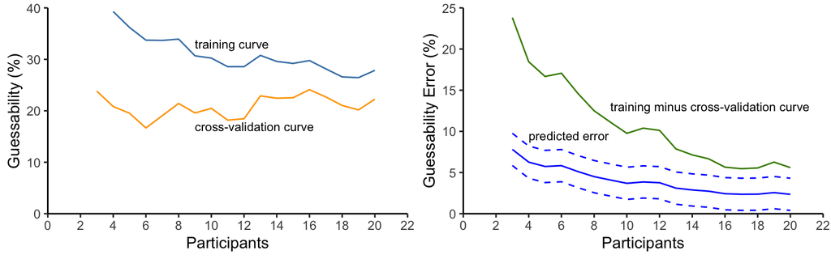

```r
library(ggplot2) # We will use ggplot2 to plot the training and cross-validation curves
library(gridExtra) # To plot the two graphs side by side

plot <- ggplot(gevolution, aes(x = N)) +
  geom_line(aes(y = validation*100), color = "orange") +
  geom_line(aes(y = training*100), color = "steelblue") +
  ylab("Guessability (%)") + xlab("Participants") +
  theme(panel.grid.major = element_blank(), panel.grid.minor = element_blank(), panel.background = element_blank(), axis.line = element_line(colour = "black")) +
  annotate("text", x = 9, y = 33, label = "training curve", size = 3, hjust = 0) +
  annotate("text", x = 9, y = 17, label = "cross-validation curve", size = 3, hjust = 0) +
  scale_x_continuous(expand = c(0, 0), breaks = seq(0, 22, 2), limits = c(0, 22)) +
  scale_y_continuous(expand = c(0, 0), limits = c(0, 40))

plot_error <- ggplot(gevolution, aes(x = N)) +
  geom_line(aes(y = (training - validation)*100), color = "chartreuse4") +
  geom_line(aes(y = fit*100), color = "blue") +
  geom_line(linetype = 2, aes(y = lwr*100), color = "blue") +
  geom_line(linetype = 2, aes(y = upr*100), color = "blue") +
  ylab("Guessability Error (%)") + xlab("Participants") +
  theme(panel.grid.major = element_blank(), panel.grid.minor = element_blank(), panel.background = element_blank(), axis.line = element_line(colour = "black")) +
  annotate("text", x = 9, y = 13, label = "training minus cross-validation curve", size = 3, hjust = 0) +
  annotate("text", x = 4, y = 9.5, label = "predicted error", size = 3, hjust = 0) +
  scale_x_continuous(expand = c(0, 0), breaks = seq(0, 22, 2), limits = c(0, 22)) +
  scale_y_continuous(expand = c(0, 0), limits = c(0, 25))

grid.arrange(plot, plot_error, ncol=2)
```

The predicted guessability error is expected to be lower than $4.5\%$, with a best guess of around $2.5\%$ – this number corresponds to a relative error of around $10\%$ with respect to the expected population guessability. The error is decreasing slowly, but the cross-validation cross still fluctuates. A sensible decision could be to opt for a large sample size, e.g., $n = 30$. However, the investigators may decide that the cost of recruiting additional participants outweighs any benefits from potential increases in guessability scores. In all cases, plotting the above graphs other researchers better interpret their results.

In the above analysis, we considered the full set of 42 referents. However, you might decide to concentrate on a smaller set of referents and adapt the optimization accordingly. Finally, if you interested in learning about how to conduct agreement analysis on the above dataset, please refer to [this page](https://www.lri.fr/~fanis/tochi2018/agreement-case-study.html).

## References

Bailly, Gilles, Thomas Pietrzak, Jonathan Deber, and Daniel J. Wigdor. 2013. “Métamorphe: Augmenting Hotkey Usage with Actuated Keys.” In *Proceedings of the Sigchi Conference on Human Factors in Computing Systems*, 563–72. CHI ’13. New York, NY, USA: ACM. https://doi.org/10.1145/2470654.2470734.

Tsandilas, Theophanis, and Pierre Dragicevic. 2022. “Gesture Elicitation as a Computational Optimization Problem.” In *CHI Conference on Human Factors in Computing Systems*. https://doi.org/10.1145/3491102.3501942.

Villarreal-Narvaez, Santiago, Jean Vanderdonckt, Radu-Daniel Vatavu, and Jacob O. Wobbrock. 2020. “A Systematic Review of Gesture Elicitation Studies: What Can We Learn from 216 Studies?” In *Proceedings of the 2020 Acm Designing Interactive Systems Conference*, 855–72. DIS ’20. New York, NY, USA: Association for Computing Machinery. https://doi.org/10.1145/3357236.3395511.

Wobbrock, Jacob O., Htet Htet Aung, Brandon Rothrock, and Brad A. Myers. 2005. “Maximizing the Guessability of Symbolic Input.” In *CHI ’05 Extended Abstracts on Human Factors in Computing Systems*, 1869–72. CHI Ea ’05. New York, NY, USA: ACM. https://doi.org/10.1145/1056808.1057043.